# Optimal Treatment Analysis

## Outcome Variable

**Outcome Variable:** ever_wasted

## Predictor Variables

**Intervention Variable:** parity

**Adjustment Set:**

- arm
- W_mage
- meducyrs
- feducyrs
- W_mhtcm
- vagbrth
- single
- delta_W_mage
- delta_meducyrs
- delta_feducyrs
- delta_W_mhtcm
- delta_vagbrth
- delta_single

## Stratifying Variables

The analysis was stratified on these variable(s):

- agecat
- studyid
- country

## Data Summary

| agecat | studyid | country | parity | ever_wasted | n_cell | n |
| --- | --- | --- | --- | --- | --- | --- |
| 0-24 months | ki1000304b-SAS-CompFeed | INDIA | 1 | 0 | 96 | 463 |
| 0-24 months | ki1000304b-SAS-CompFeed | INDIA | 1 | 1 | 46 | 463 |
| 0-24 months | ki1000304b-SAS-CompFeed | INDIA | 2 | 0 | 68 | 463 |
| 0-24 months | ki1000304b-SAS-CompFeed | INDIA | 2 | 1 | 37 | 463 |
| 0-24 months | ki1000304b-SAS-CompFeed | INDIA | 3+ | 0 | 122 | 463 |
| 0-24 months | ki1000304b-SAS-CompFeed | INDIA | 3+ | 1 | 94 | 463 |
| 0-24 months | ki1000304b-SAS-FoodSuppl | INDIA | 1 | 0 | 11 | 101 |
| 0-24 months | ki1000304b-SAS-FoodSuppl | INDIA | 1 | 1 | 8 | 101 |
| 0-24 months | ki1000304b-SAS-FoodSuppl | INDIA | 2 | 0 | 10 | 101 |
| 0-24 months | ki1000304b-SAS-FoodSuppl | INDIA | 2 | 1 | 11 | 101 |
| 0-24 months | ki1000304b-SAS-FoodSuppl | INDIA | 3+ | 0 | 30 | 101 |
| 0-24 months | ki1000304b-SAS-FoodSuppl | INDIA | 3+ | 1 | 31 | 101 |
| 0-24 months | ki1017093b-PROVIDE | BANGLADESH | 1 | 0 | 163 | 700 |
| 0-24 months | ki1017093b-PROVIDE | BANGLADESH | 1 | 1 | 108 | 700 |
| 0-24 months | ki1017093b-PROVIDE | BANGLADESH | 2 | 0 | 170 | 700 |
| 0-24 months | ki1017093b-PROVIDE | BANGLADESH | 2 | 1 | 74 | 700 |
| 0-24 months | ki1017093b-PROVIDE | BANGLADESH | 3+ | 0 | 121 | 700 |
| 0-24 months | ki1017093b-PROVIDE | BANGLADESH | 3+ | 1 | 64 | 700 |
| 0-24 months | ki1066203-TanzaniaChild2 | TANZANIA, UNITED REPUBLIC OF | 1 | 0 | 624 | 2357 |
| 0-24 months | ki1066203-TanzaniaChild2 | TANZANIA, UNITED REPUBLIC OF | 1 | 1 | 197 | 2357 |
| 0-24 months | ki1066203-TanzaniaChild2 | TANZANIA, UNITED REPUBLIC OF | 2 | 0 | 583 | 2357 |
| 0-24 months | ki1066203-TanzaniaChild2 | TANZANIA, UNITED REPUBLIC OF | 2 | 1 | 188 | 2357 |
| 0-24 months | ki1066203-TanzaniaChild2 | TANZANIA, UNITED REPUBLIC OF | 3+ | 0 | 592 | 2357 |
| 0-24 months | ki1066203-TanzaniaChild2 | TANZANIA, UNITED REPUBLIC OF | 3+ | 1 | 173 | 2357 |
| 0-24 months | ki1101329-Keneba | GAMBIA | 1 | 0 | 160 | 1989 |
| 0-24 months | ki1101329-Keneba | GAMBIA | 1 | 1 | 80 | 1989 |
| 0-24 months | ki1101329-Keneba | GAMBIA | 2 | 0 | 138 | 1989 |
| 0-24 months | ki1101329-Keneba | GAMBIA | 2 | 1 | 76 | 1989 |
| 0-24 months | ki1101329-Keneba | GAMBIA | 3+ | 0 | 887 | 1989 |
| 0-24 months | ki1101329-Keneba | GAMBIA | 3+ | 1 | 648 | 1989 |

[output cut: 168 more lines]

The following strata were considered:

- agecat: 0-24 months, studyid: ki1000304b-SAS-CompFeed, country: INDIA
- agecat: 0-24 months, studyid: ki1000304b-SAS-FoodSuppl, country: INDIA
- agecat: 0-24 months, studyid: ki1017093b-PROVIDE, country: BANGLADESH
- agecat: 0-24 months, studyid: ki1066203-TanzaniaChild2, country: TANZANIA, UNITED REPUBLIC OF
- agecat: 0-24 months, studyid: ki1101329-Keneba, country: GAMBIA
- agecat: 0-24 months, studyid: ki1113344-GMS-Nepal, country: NEPAL
- agecat: 0-24 months, studyid: ki1126311-ZVITAMBO, country: ZIMBABWE
- agecat: 0-24 months, studyid: ki1135781-COHORTS, country: GUATEMALA
- agecat: 0-24 months, studyid: ki1135781-COHORTS, country: INDIA
- agecat: 0-24 months, studyid: ki1135781-COHORTS, country: PHILIPPINES
- agecat: 0-24 months, studyid: kiGH5241-JiVitA-3, country: BANGLADESH
- agecat: 0-6 months, studyid: ki1000304b-SAS-CompFeed, country: INDIA
- agecat: 0-6 months, studyid: ki1000304b-SAS-FoodSuppl, country: INDIA
- agecat: 0-6 months, studyid: ki1017093b-PROVIDE, country: BANGLADESH
- agecat: 0-6 months, studyid: ki1066203-TanzaniaChild2, country: TANZANIA, UNITED REPUBLIC OF
- agecat: 0-6 months, studyid: ki1101329-Keneba, country: GAMBIA
- agecat: 0-6 months, studyid: ki1113344-GMS-Nepal, country: NEPAL
- agecat: 0-6 months, studyid: ki1126311-ZVITAMBO, country: ZIMBABWE
- agecat: 0-6 months, studyid: ki1135781-COHORTS, country: GUATEMALA
- agecat: 0-6 months, studyid: ki1135781-COHORTS, country: INDIA
- agecat: 0-6 months, studyid: ki1135781-COHORTS, country: PHILIPPINES
- agecat: 0-6 months, studyid: kiGH5241-JiVitA-3, country: BANGLADESH
- agecat: 6-24 months, studyid: ki1000304b-SAS-CompFeed, country: INDIA
- agecat: 6-24 months, studyid: ki1000304b-SAS-FoodSuppl, country: INDIA
- agecat: 6-24 months, studyid: ki1017093b-PROVIDE, country: BANGLADESH
- agecat: 6-24 months, studyid: ki1066203-TanzaniaChild2, country: TANZANIA, UNITED REPUBLIC OF
- agecat: 6-24 months, studyid: ki1101329-Keneba, country: GAMBIA
- agecat: 6-24 months, studyid: ki1113344-GMS-Nepal, country: NEPAL
- agecat: 6-24 months, studyid: ki1126311-ZVITAMBO, country: ZIMBABWE
- agecat: 6-24 months, studyid: ki1135781-COHORTS, country: GUATEMALA
- agecat: 6-24 months, studyid: ki1135781-COHORTS, country: INDIA
- agecat: 6-24 months, studyid: ki1135781-COHORTS, country: PHILIPPINES
- agecat: 6-24 months, studyid: kiGH5241-JiVitA-3, country: BANGLADESH

### Dropped Strata

Some strata were dropped due to rare outcomes:

- agecat: 0-6 months, studyid: ki1000304b-SAS-FoodSuppl, country: INDIA

## Methods Detail

We’re interested in the causal parameters $E[Y_a]$ for all values of $a \in \mathcal{A}$. These parameters represent the mean outcome if, possibly contrary to fact, we intervened to set all units to have $A=a$. Under the randomization and positivity assumptions, these are identified by the statistical parameters $\psi_a=E_W[E_{Y|A,W}(Y|A=a,W)]$. In addition, we’re interested in the mean of $Y$, $E[Y]$ under no intervention (the observed mean). We will estimate these parameters by using SuperLearner to fit the relevant likelihood factors – $E_{Y|A,W}(Y|A=a,W)$ and $p(A=a|W)$, and then updating our likelihood fit using a joint TMLE.

For unadjusted analyses ($W=\{\}$), initial likelihoods were estimated using Lrnr_glm to estimate the simple $E(Y|A)$ and Lrnr_mean to estimate $p(A)$. For adjusted analyses, a small library containing Lrnr_glmnet, Lrnr_xgboost, and Lrnr_mean was used.

Having estimated these parameters, we will then use the delta method to estimate relative risks and attributable risks relative to a prespecified baseline level of $A$.

# Results Detail

## Results Plots

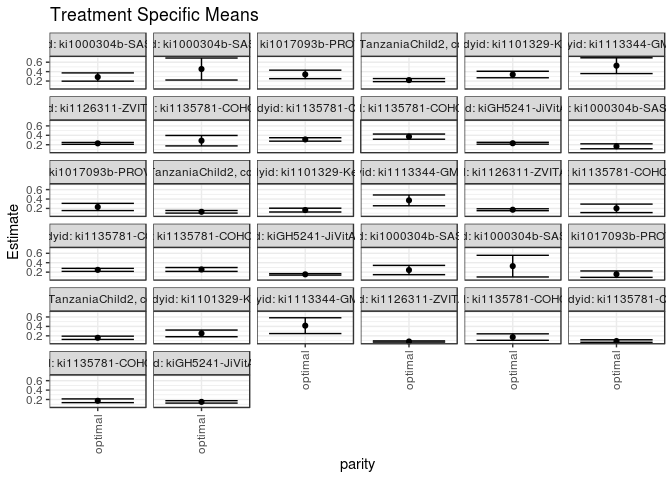

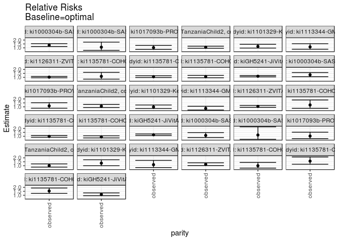

## Results Table

### Parameter: TSM

| agecat | studyid | country | intervention_level | baseline_level | estimate | ci_lower | ci_upper |
| --- | --- | --- | --- | --- | --- | --- | --- |
| 0-24 months | ki1000304b-SAS-CompFeed | INDIA | optimal | NA | 0.2852413 | 0.1977412 | 0.3727413 |
| 0-24 months | ki1000304b-SAS-FoodSuppl | INDIA | optimal | NA | 0.4550933 | 0.2214681 | 0.6887184 |
| 0-24 months | ki1017093b-PROVIDE | BANGLADESH | optimal | NA | 0.3407125 | 0.2504640 | 0.4309611 |
| 0-24 months | ki1066203-TanzaniaChild2 | TANZANIA, UNITED REPUBLIC OF | optimal | NA | 0.2204989 | 0.1879594 | 0.2530385 |
| 0-24 months | ki1101329-Keneba | GAMBIA | optimal | NA | 0.3387226 | 0.2697280 | 0.4077173 |
| 0-24 months | ki1113344-GMS-Nepal | NEPAL | optimal | NA | 0.5264377 | 0.3591183 | 0.6937571 |
| 0-24 months | ki1126311-ZVITAMBO | ZIMBABWE | optimal | NA | 0.2292790 | 0.2093884 | 0.2491697 |
| 0-24 months | ki1135781-COHORTS | GUATEMALA | optimal | NA | 0.2863134 | 0.1757116 | 0.3969151 |
| 0-24 months | ki1135781-COHORTS | INDIA | optimal | NA | 0.3125490 | 0.2761782 | 0.3489199 |
| 0-24 months | ki1135781-COHORTS | PHILIPPINES | optimal | NA | 0.3717861 | 0.3170556 | 0.4265166 |
| 0-24 months | kiGH5241-JiVitA-3 | BANGLADESH | optimal | NA | 0.2319259 | 0.2119205 | 0.2519313 |
| 0-6 months | ki1000304b-SAS-CompFeed | INDIA | optimal | NA | 0.1672320 | 0.1149089 | 0.2195551 |
| 0-6 months | ki1017093b-PROVIDE | BANGLADESH | optimal | NA | 0.2311148 | 0.1547422 | 0.3074873 |
| 0-6 months | ki1066203-TanzaniaChild2 | TANZANIA, UNITED REPUBLIC OF | optimal | NA | 0.1289392 | 0.1013363 | 0.1565420 |
| 0-6 months | ki1101329-Keneba | GAMBIA | optimal | NA | 0.1647062 | 0.1242204 | 0.2051920 |
| 0-6 months | ki1113344-GMS-Nepal | NEPAL | optimal | NA | 0.3714215 | 0.2570543 | 0.4857887 |
| 0-6 months | ki1126311-ZVITAMBO | ZIMBABWE | optimal | NA | 0.1725545 | 0.1517835 | 0.1933256 |
| 0-6 months | ki1135781-COHORTS | GUATEMALA | optimal | NA | 0.2018105 | 0.1113994 | 0.2922217 |
| 0-6 months | ki1135781-COHORTS | INDIA | optimal | NA | 0.2482611 | 0.2163154 | 0.2802069 |
| 0-6 months | ki1135781-COHORTS | PHILIPPINES | optimal | NA | 0.2564649 | 0.2154462 | 0.2974837 |
| 0-6 months | kiGH5241-JiVitA-3 | BANGLADESH | optimal | NA | 0.1527743 | 0.1373549 | 0.1681937 |
| 6-24 months | ki1000304b-SAS-CompFeed | INDIA | optimal | NA | 0.2443929 | 0.1460000 | 0.3427858 |
| 6-24 months | ki1000304b-SAS-FoodSuppl | INDIA | optimal | NA | 0.3276276 | 0.0977739 | 0.5574812 |
| 6-24 months | ki1017093b-PROVIDE | BANGLADESH | optimal | NA | 0.1563918 | 0.0883842 | 0.2243994 |
| 6-24 months | ki1066203-TanzaniaChild2 | TANZANIA, UNITED REPUBLIC OF | optimal | NA | 0.1581757 | 0.1237122 | 0.1926392 |
| 6-24 months | ki1101329-Keneba | GAMBIA | optimal | NA | 0.2515268 | 0.1806989 | 0.3223548 |
| 6-24 months | ki1113344-GMS-Nepal | NEPAL | optimal | NA | 0.4157193 | 0.2482085 | 0.5832302 |
| 6-24 months | ki1126311-ZVITAMBO | ZIMBABWE | optimal | NA | 0.0795427 | 0.0668770 | 0.0922084 |
| 6-24 months | ki1135781-COHORTS | GUATEMALA | optimal | NA | 0.1732999 | 0.1047525 | 0.2418473 |
| 6-24 months | ki1135781-COHORTS | INDIA | optimal | NA | 0.0892971 | 0.0627937 | 0.1158004 |
| 6-24 months | ki1135781-COHORTS | PHILIPPINES | optimal | NA | 0.1734756 | 0.1336457 | 0.2133055 |
| 6-24 months | kiGH5241-JiVitA-3 | BANGLADESH | optimal | NA | 0.1497562 | 0.1243712 | 0.1751413 |

### Parameter: E(Y)

| agecat | studyid | country | intervention_level | baseline_level | estimate | ci_lower | ci_upper |
| --- | --- | --- | --- | --- | --- | --- | --- |
| 0-24 months | ki1000304b-SAS-CompFeed | INDIA | observed | NA | 0.3822894 | 0.3008363 | 0.4637425 |
| 0-24 months | ki1000304b-SAS-FoodSuppl | INDIA | observed | NA | 0.4950495 | 0.3970561 | 0.5930429 |
| 0-24 months | ki1017093b-PROVIDE | BANGLADESH | observed | NA | 0.3514286 | 0.3160364 | 0.3868207 |
| 0-24 months | ki1066203-TanzaniaChild2 | TANZANIA, UNITED REPUBLIC OF | observed | NA | 0.2367416 | 0.2195770 | 0.2539062 |
| 0-24 months | ki1101329-Keneba | GAMBIA | observed | NA | 0.4042232 | 0.3826511 | 0.4257953 |
| 0-24 months | ki1113344-GMS-Nepal | NEPAL | observed | NA | 0.5913621 | 0.5520608 | 0.6306634 |
| 0-24 months | ki1126311-ZVITAMBO | ZIMBABWE | observed | NA | 0.2347539 | 0.2277172 | 0.2417906 |
| 0-24 months | ki1135781-COHORTS | GUATEMALA | observed | NA | 0.3216463 | 0.2858742 | 0.3574185 |
| 0-24 months | ki1135781-COHORTS | INDIA | observed | NA | 0.3378028 | 0.3241691 | 0.3514364 |
| 0-24 months | ki1135781-COHORTS | PHILIPPINES | observed | NA | 0.4036125 | 0.3861835 | 0.4210415 |
| 0-24 months | kiGH5241-JiVitA-3 | BANGLADESH | observed | NA | 0.2641779 | 0.2551015 | 0.2732542 |
| 0-6 months | ki1000304b-SAS-CompFeed | INDIA | observed | NA | 0.2207792 | 0.1636864 | 0.2778721 |
| 0-6 months | ki1017093b-PROVIDE | BANGLADESH | observed | NA | 0.2585714 | 0.2261125 | 0.2910304 |
| 0-6 months | ki1066203-TanzaniaChild2 | TANZANIA, UNITED REPUBLIC OF | observed | NA | 0.1395842 | 0.1255905 | 0.1535779 |
| 0-6 months | ki1101329-Keneba | GAMBIA | observed | NA | 0.1613611 | 0.1444653 | 0.1782570 |
| 0-6 months | ki1113344-GMS-Nepal | NEPAL | observed | NA | 0.2956811 | 0.2591967 | 0.3321655 |
| 0-6 months | ki1126311-ZVITAMBO | ZIMBABWE | observed | NA | 0.1810631 | 0.1746489 | 0.1874773 |
| 0-6 months | ki1135781-COHORTS | GUATEMALA | observed | NA | 0.2485323 | 0.2110255 | 0.2860391 |
| 0-6 months | ki1135781-COHORTS | INDIA | observed | NA | 0.2434743 | 0.2308547 | 0.2560940 |
| 0-6 months | ki1135781-COHORTS | PHILIPPINES | observed | NA | 0.2355453 | 0.2204685 | 0.2506222 |
| 0-6 months | kiGH5241-JiVitA-3 | BANGLADESH | observed | NA | 0.1822226 | 0.1742229 | 0.1902222 |
| 6-24 months | ki1000304b-SAS-CompFeed | INDIA | observed | NA | 0.2708333 | 0.2169112 | 0.3247555 |
| 6-24 months | ki1000304b-SAS-FoodSuppl | INDIA | observed | NA | 0.3800000 | 0.2843867 | 0.4756133 |
| 6-24 months | ki1017093b-PROVIDE | BANGLADESH | observed | NA | 0.1609756 | 0.1319065 | 0.1900447 |
| 6-24 months | ki1066203-TanzaniaChild2 | TANZANIA, UNITED REPUBLIC OF | observed | NA | 0.1600403 | 0.1439152 | 0.1761654 |
| 6-24 months | ki1101329-Keneba | GAMBIA | observed | NA | 0.3341996 | 0.3131165 | 0.3552826 |
| 6-24 months | ki1113344-GMS-Nepal | NEPAL | observed | NA | 0.4728814 | 0.4325613 | 0.5132014 |
| 6-24 months | ki1126311-ZVITAMBO | ZIMBABWE | observed | NA | 0.0939867 | 0.0884555 | 0.0995179 |
| 6-24 months | ki1135781-COHORTS | GUATEMALA | observed | NA | 0.1731092 | 0.1426836 | 0.2035348 |
| 6-24 months | ki1135781-COHORTS | INDIA | observed | NA | 0.1419682 | 0.1315821 | 0.1523542 |
| 6-24 months | ki1135781-COHORTS | PHILIPPINES | observed | NA | 0.2666429 | 0.2502871 | 0.2829988 |
| 6-24 months | kiGH5241-JiVitA-3 | BANGLADESH | observed | NA | 0.1648146 | 0.1556271 | 0.1740021 |

### Parameter: RR

| agecat | studyid | country | intervention_level | baseline_level | estimate | ci_lower | ci_upper |
| --- | --- | --- | --- | --- | --- | --- | --- |
| 0-24 months | ki1000304b-SAS-CompFeed | INDIA | observed | optimal | 1.3402319 | 1.1702550 | 1.534897 |
| 0-24 months | ki1000304b-SAS-FoodSuppl | INDIA | observed | optimal | 1.0877979 | 0.6838375 | 1.730388 |
| 0-24 months | ki1017093b-PROVIDE | BANGLADESH | observed | optimal | 1.0314518 | 0.8092599 | 1.314649 |
| 0-24 months | ki1066203-TanzaniaChild2 | TANZANIA, UNITED REPUBLIC OF | observed | optimal | 1.0736634 | 0.9464048 | 1.218034 |
| 0-24 months | ki1101329-Keneba | GAMBIA | observed | optimal | 1.1933753 | 0.9781801 | 1.455912 |
| 0-24 months | ki1113344-GMS-Nepal | NEPAL | observed | optimal | 1.1233279 | 0.8266315 | 1.526515 |
| 0-24 months | ki1126311-ZVITAMBO | ZIMBABWE | observed | optimal | 1.0238787 | 0.9443489 | 1.110106 |
| 0-24 months | ki1135781-COHORTS | GUATEMALA | observed | optimal | 1.1234067 | 0.7736159 | 1.631355 |
| 0-24 months | ki1135781-COHORTS | INDIA | observed | optimal | 1.0807994 | 0.9692880 | 1.205140 |
| 0-24 months | ki1135781-COHORTS | PHILIPPINES | observed | optimal | 1.0856040 | 0.9450789 | 1.247024 |
| 0-24 months | kiGH5241-JiVitA-3 | BANGLADESH | observed | optimal | 1.1390617 | 1.0573469 | 1.227092 |
| 0-6 months | ki1000304b-SAS-CompFeed | INDIA | observed | optimal | 1.3201972 | 1.0827248 | 1.609754 |
| 0-6 months | ki1017093b-PROVIDE | BANGLADESH | observed | optimal | 1.1188010 | 0.8241587 | 1.518780 |
| 0-6 months | ki1066203-TanzaniaChild2 | TANZANIA, UNITED REPUBLIC OF | observed | optimal | 1.0825587 | 0.9001617 | 1.301914 |
| 0-6 months | ki1101329-Keneba | GAMBIA | observed | optimal | 0.9796908 | 0.7812527 | 1.228532 |
| 0-6 months | ki1113344-GMS-Nepal | NEPAL | observed | optimal | 0.7960796 | 0.5909033 | 1.072498 |
| 0-6 months | ki1126311-ZVITAMBO | ZIMBABWE | observed | optimal | 1.0493095 | 0.9350171 | 1.177572 |
| 0-6 months | ki1135781-COHORTS | GUATEMALA | observed | optimal | 1.2315131 | 0.8119714 | 1.867830 |
| 0-6 months | ki1135781-COHORTS | INDIA | observed | optimal | 0.9807188 | 0.8722642 | 1.102658 |
| 0-6 months | ki1135781-COHORTS | PHILIPPINES | observed | optimal | 0.9184309 | 0.7941120 | 1.062212 |
| 0-6 months | kiGH5241-JiVitA-3 | BANGLADESH | observed | optimal | 1.1927568 | 1.0955870 | 1.298545 |
| 6-24 months | ki1000304b-SAS-CompFeed | INDIA | observed | optimal | 1.1081882 | 0.8393415 | 1.463148 |
| 6-24 months | ki1000304b-SAS-FoodSuppl | INDIA | observed | optimal | 1.1598535 | 0.6117552 | 2.199017 |
| 6-24 months | ki1017093b-PROVIDE | BANGLADESH | observed | optimal | 1.0293098 | 0.6984391 | 1.516923 |
| 6-24 months | ki1066203-TanzaniaChild2 | TANZANIA, UNITED REPUBLIC OF | observed | optimal | 1.0117877 | 0.8306462 | 1.232431 |
| 6-24 months | ki1101329-Keneba | GAMBIA | observed | optimal | 1.3286837 | 1.0061931 | 1.754535 |
| 6-24 months | ki1113344-GMS-Nepal | NEPAL | observed | optimal | 1.1375015 | 0.7699508 | 1.680510 |
| 6-24 months | ki1126311-ZVITAMBO | ZIMBABWE | observed | optimal | 1.1815880 | 1.0192148 | 1.369829 |
| 6-24 months | ki1135781-COHORTS | GUATEMALA | observed | optimal | 0.9989000 | 0.7005949 | 1.424220 |
| 6-24 months | ki1135781-COHORTS | INDIA | observed | optimal | 1.5898417 | 1.1929800 | 2.118725 |
| 6-24 months | ki1135781-COHORTS | PHILIPPINES | observed | optimal | 1.5370631 | 1.2334602 | 1.915394 |
| 6-24 months | kiGH5241-JiVitA-3 | BANGLADESH | observed | optimal | 1.1005524 | 0.9396262 | 1.289040 |

### Parameter: PAR

| agecat | studyid | country | intervention_level | baseline_level | estimate | ci_lower | ci_upper |
| --- | --- | --- | --- | --- | --- | --- | --- |
| 0-24 months | ki1000304b-SAS-CompFeed | INDIA | optimal | NA | 0.0970482 | 0.0641085 | 0.1299879 |
| 0-24 months | ki1000304b-SAS-FoodSuppl | INDIA | optimal | NA | 0.0399562 | -0.1710594 | 0.2509719 |
| 0-24 months | ki1017093b-PROVIDE | BANGLADESH | optimal | NA | 0.0107160 | -0.0719230 | 0.0933551 |
| 0-24 months | ki1066203-TanzaniaChild2 | TANZANIA, UNITED REPUBLIC OF | optimal | NA | 0.0162427 | -0.0115618 | 0.0440472 |
| 0-24 months | ki1101329-Keneba | GAMBIA | optimal | NA | 0.0655006 | -0.0020917 | 0.1330929 |
| 0-24 months | ki1113344-GMS-Nepal | NEPAL | optimal | NA | 0.0649245 | -0.0963183 | 0.2261672 |
| 0-24 months | ki1126311-ZVITAMBO | ZIMBABWE | optimal | NA | 0.0054749 | -0.0130618 | 0.0240115 |
| 0-24 months | ki1135781-COHORTS | GUATEMALA | optimal | NA | 0.0353330 | -0.0716563 | 0.1423223 |
| 0-24 months | ki1135781-COHORTS | INDIA | optimal | NA | 0.0252538 | -0.0087900 | 0.0592975 |
| 0-24 months | ki1135781-COHORTS | PHILIPPINES | optimal | NA | 0.0318264 | -0.0196625 | 0.0833153 |
| 0-24 months | kiGH5241-JiVitA-3 | BANGLADESH | optimal | NA | 0.0322520 | 0.0151075 | 0.0493966 |
| 0-6 months | ki1000304b-SAS-CompFeed | INDIA | optimal | NA | 0.0535472 | 0.0165902 | 0.0905043 |
| 0-6 months | ki1017093b-PROVIDE | BANGLADESH | optimal | NA | 0.0274567 | -0.0432667 | 0.0981800 |
| 0-6 months | ki1066203-TanzaniaChild2 | TANZANIA, UNITED REPUBLIC OF | optimal | NA | 0.0106451 | -0.0131192 | 0.0344093 |
| 0-6 months | ki1101329-Keneba | GAMBIA | optimal | NA | -0.0033450 | -0.0406129 | 0.0339228 |
| 0-6 months | ki1113344-GMS-Nepal | NEPAL | optimal | NA | -0.0757404 | -0.1856586 | 0.0341777 |
| 0-6 months | ki1126311-ZVITAMBO | ZIMBABWE | optimal | NA | 0.0085086 | -0.0113956 | 0.0284127 |
| 0-6 months | ki1135781-COHORTS | GUATEMALA | optimal | NA | 0.0467218 | -0.0373864 | 0.1308300 |
| 0-6 months | ki1135781-COHORTS | INDIA | optimal | NA | -0.0047868 | -0.0338852 | 0.0243117 |
| 0-6 months | ki1135781-COHORTS | PHILIPPINES | optimal | NA | -0.0209196 | -0.0582682 | 0.0164290 |
| 0-6 months | kiGH5241-JiVitA-3 | BANGLADESH | optimal | NA | 0.0294483 | 0.0165821 | 0.0423145 |
| 6-24 months | ki1000304b-SAS-CompFeed | INDIA | optimal | NA | 0.0264404 | -0.0394904 | 0.0923712 |
| 6-24 months | ki1000304b-SAS-FoodSuppl | INDIA | optimal | NA | 0.0523724 | -0.1568259 | 0.2615707 |
| 6-24 months | ki1017093b-PROVIDE | BANGLADESH | optimal | NA | 0.0045838 | -0.0560338 | 0.0652015 |
| 6-24 months | ki1066203-TanzaniaChild2 | TANZANIA, UNITED REPUBLIC OF | optimal | NA | 0.0018645 | -0.0293469 | 0.0330760 |
| 6-24 months | ki1101329-Keneba | GAMBIA | optimal | NA | 0.0826728 | 0.0122577 | 0.1530878 |
| 6-24 months | ki1113344-GMS-Nepal | NEPAL | optimal | NA | 0.0571620 | -0.1049468 | 0.2192709 |
| 6-24 months | ki1126311-ZVITAMBO | ZIMBABWE | optimal | NA | 0.0144440 | 0.0026567 | 0.0262313 |
| 6-24 months | ki1135781-COHORTS | GUATEMALA | optimal | NA | -0.0001906 | -0.0616643 | 0.0612831 |
| 6-24 months | ki1135781-COHORTS | INDIA | optimal | NA | 0.0526711 | 0.0267630 | 0.0785792 |
| 6-24 months | ki1135781-COHORTS | PHILIPPINES | optimal | NA | 0.0931673 | 0.0546800 | 0.1316547 |
| 6-24 months | kiGH5241-JiVitA-3 | BANGLADESH | optimal | NA | 0.0150584 | -0.0086006 | 0.0387173 |

### Parameter: PAF

| agecat | studyid | country | intervention_level | baseline_level | estimate | ci_lower | ci_upper |
| --- | --- | --- | --- | --- | --- | --- | --- |
| 0-24 months | ki1000304b-SAS-CompFeed | INDIA | optimal | NA | 0.2538604 | 0.1454854 | 0.3484907 |
| 0-24 months | ki1000304b-SAS-FoodSuppl | INDIA | optimal | NA | 0.0807116 | -0.4623356 | 0.4220949 |
| 0-24 months | ki1017093b-PROVIDE | BANGLADESH | optimal | NA | 0.0304927 | -0.2356970 | 0.2393408 |
| 0-24 months | ki1066203-TanzaniaChild2 | TANZANIA, UNITED REPUBLIC OF | optimal | NA | 0.0686094 | -0.0566303 | 0.1790048 |
| 0-24 months | ki1101329-Keneba | GAMBIA | optimal | NA | 0.1620407 | -0.0223066 | 0.3131455 |
| 0-24 months | ki1113344-GMS-Nepal | NEPAL | optimal | NA | 0.1097880 | -0.2097290 | 0.3449132 |
| 0-24 months | ki1126311-ZVITAMBO | ZIMBABWE | optimal | NA | 0.0233218 | -0.0589307 | 0.0991852 |
| 0-24 months | ki1135781-COHORTS | GUATEMALA | optimal | NA | 0.1098504 | -0.2926311 | 0.3870128 |
| 0-24 months | ki1135781-COHORTS | INDIA | optimal | NA | 0.0747589 | -0.0316851 | 0.1702206 |
| 0-24 months | ki1135781-COHORTS | PHILIPPINES | optimal | NA | 0.0788538 | -0.0581128 | 0.1980909 |
| 0-24 months | kiGH5241-JiVitA-3 | BANGLADESH | optimal | NA | 0.1220844 | 0.0542366 | 0.1850650 |
| 0-6 months | ki1000304b-SAS-CompFeed | INDIA | optimal | NA | 0.2425374 | 0.0764043 | 0.3787870 |
| 0-6 months | ki1017093b-PROVIDE | BANGLADESH | optimal | NA | 0.1061860 | -0.2133585 | 0.3415768 |
| 0-6 months | ki1066203-TanzaniaChild2 | TANZANIA, UNITED REPUBLIC OF | optimal | NA | 0.0762626 | -0.1109115 | 0.2319003 |
| 0-6 months | ki1101329-Keneba | GAMBIA | optimal | NA | -0.0207302 | -0.2799956 | 0.1860205 |
| 0-6 months | ki1113344-GMS-Nepal | NEPAL | optimal | NA | -0.2561558 | -0.6923244 | 0.0675975 |
| 0-6 months | ki1126311-ZVITAMBO | ZIMBABWE | optimal | NA | 0.0469923 | -0.0694991 | 0.1507954 |
| 0-6 months | ki1135781-COHORTS | GUATEMALA | optimal | NA | 0.1879907 | -0.2315705 | 0.4646193 |
| 0-6 months | ki1135781-COHORTS | INDIA | optimal | NA | -0.0196603 | -0.1464417 | 0.0931007 |
| 0-6 months | ki1135781-COHORTS | PHILIPPINES | optimal | NA | -0.0888135 | -0.2592682 | 0.0585684 |
| 0-6 months | kiGH5241-JiVitA-3 | BANGLADESH | optimal | NA | 0.1616061 | 0.0872473 | 0.2299072 |
| 6-24 months | ki1000304b-SAS-CompFeed | INDIA | optimal | NA | 0.0976262 | -0.1914101 | 0.3165422 |
| 6-24 months | ki1000304b-SAS-FoodSuppl | INDIA | optimal | NA | 0.1378222 | -0.6346408 | 0.5452514 |
| 6-24 months | ki1017093b-PROVIDE | BANGLADESH | optimal | NA | 0.0284752 | -0.4317641 | 0.3407709 |
| 6-24 months | ki1066203-TanzaniaChild2 | TANZANIA, UNITED REPUBLIC OF | optimal | NA | 0.0116504 | -0.2038820 | 0.1885958 |
| 6-24 months | ki1101329-Keneba | GAMBIA | optimal | NA | 0.2473754 | 0.0061550 | 0.4300483 |
| 6-24 months | ki1113344-GMS-Nepal | NEPAL | optimal | NA | 0.1208803 | -0.2987843 | 0.4049424 |
| 6-24 months | ki1126311-ZVITAMBO | ZIMBABWE | optimal | NA | 0.1536813 | 0.0188525 | 0.2699820 |
| 6-24 months | ki1135781-COHORTS | GUATEMALA | optimal | NA | -0.0011012 | -0.4273585 | 0.2978613 |
| 6-24 months | ki1135781-COHORTS | INDIA | optimal | NA | 0.3710066 | 0.1617630 | 0.5280181 |
| 6-24 months | ki1135781-COHORTS | PHILIPPINES | optimal | NA | 0.3494086 | 0.1892726 | 0.4779143 |
| 6-24 months | kiGH5241-JiVitA-3 | BANGLADESH | optimal | NA | 0.0913654 | -0.0642530 | 0.2242288 |